# Practical Machine Learning Assignment

## Assignment Summary [From Coursera]

Using devices such as Jawbone Up, Nike FuelBand, and Fitbit it is now possible to collect a large amount of data about personal activity relatively inexpensively. These type of devices are part of the quantified self movement - a group of enthusiasts who take measurements about themselves regularly to improve their health, to find patterns in their behavior, or because they are tech geeks. One thing that people regularly do is quantify how much of a particular activity they do, but they rarely quantify how well they do it. In this project, your goal will be to use data from accelerometers on the belt, forearm, arm, and dumbell of 6 participants. They were asked to perform barbell lifts correctly and incorrectly in 5 different ways.

## Assignment Goals

The goal of the assingment is to predict the manner in which candidates did certain exercises. This is described via the “classe” variable in the training set. The following assignment will decribe the steps in building a predictive model, evaluating it via a test set and the expected out of sample error resulting from such a model. This model will then be further applied for 20 different test cases.

## Loading Relevant Packages

The assignment requires a range of different packages for training and testing of the machine learning algorithms. These packages are the following:

```r
library(caret)
library(randomForest)
```

```r
library(rpart)
library(rpart.plot)
library(corrplot)
```

## Gather Data

The data has been saved locally on the desktop. Hence reading the data will be completed via the read.csv command. Alternatively one can download the data directly from the source url. The data will then pass through a series of operations to clean it and make it usuable for the machine learning algorithms.

```r
setwd("C:/Users/kh/Desktop/Machine_Learning/Assignment/")
train_data <-read.csv("pml-training.csv")
train_data_classe <- train_data$classe
train_data <- train_data[,colSums(is.na(train_data))==0]
train_data <- train_data[, !grepl("^X|timestamp|window", names(train_data))]
train_data <- train_data[, sapply(train_data, is.numeric)]
train_data$classe <- train_data_classe
test_data <-read.csv("pml-testing.csv")
test_data_classe <- test_data$classe
test_data <- test_data[,colSums(is.na(test_data))==0]
test_data <- test_data[, !grepl("^X|timestamp|window", names(test_data))]
test_data <- test_data[, sapply(test_data, is.numeric)]
test_data$classe <- test_data_classe
```

## Seperation of Training and Testing sets within Training Set

Leaving the test_data as a final validation mechanism (also as a means of out of sample evaluation), the training data set is partitioned into two sets with 60% used for training the machine learning algorithm and 40% used for validation.

```r
inTrain <- createDataPartition(y=train_data$classe, p=0.6, list=FALSE)
training <- train_data[inTrain,]
testing <- train_data[-inTrain,]
dim(training)
```

```
## [1] 11776    53
```

```r
dim(testing)
```

```
## [1] 7846   53
```

## Model The Data Using Tree Method

Once the data is cleaned a simple tree method can be used as a training mechanism for the data. This can be seen below.

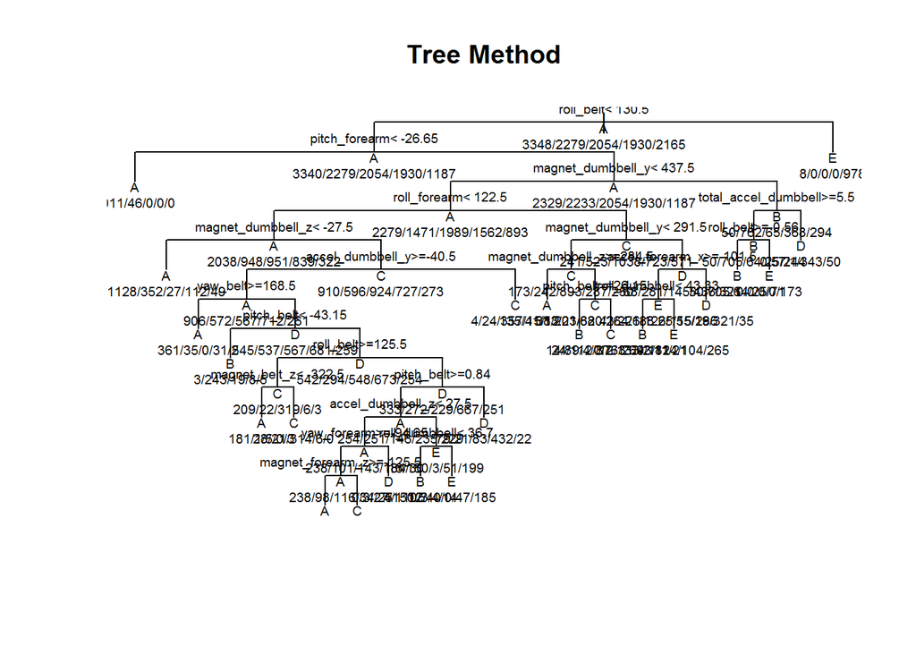

```r
mod_TM <- rpart(classe~.,data=training, method="class")
plot(mod_TM, uniform=TRUE, main="Tree Method")
text(mod_TM, use.n=TRUE, all=TRUE, cex=.6)
```

```r
post(mod_TM)
```

Using this Tree method the model can be applied to the test data for prediction evaulation. This is shown below whereby a confusion matrix is used estimate performance.

```r
predict_TM <- predict(mod_TM, testing, type="class")
confusionMatrix(predict_TM, testing$classe)
```

```
## Confusion Matrix and Statistics
##
##           Reference
## Prediction    A    B    C    D    E
##          A 2023  344   27  163   83
##          B   54  837   69   37   92
##          C   46  131 1102  182  165
##          D   82  117   81  789   71
##          E   27   89   89  115 1031
##
## Overall Statistics
##
##                Accuracy : 0.7369
##                  95% CI : (0.727, 0.7467)
##     No Information Rate : 0.2845
##     P-Value [Acc > NIR] : < 2.2e-16
##
##                   Kappa : 0.6652
##  Mcnemar's Test P-Value : < 2.2e-16
##
## Statistics by Class:
##
##                      Class: A Class: B Class: C Class: D Class: E
## Sensitivity            0.9064   0.5514   0.8056   0.6135   0.7150
## Specificity            0.8901   0.9602   0.9191   0.9465   0.9500
## Pos Pred Value         0.7663   0.7686   0.6777   0.6921   0.7631
## Neg Pred Value         0.9599   0.8992   0.9572   0.9259   0.9367
## Prevalence             0.2845   0.1935   0.1744   0.1639   0.1838
## Detection Rate         0.2578   0.1067   0.1405   0.1006   0.1314
## Detection Prevalence   0.3365   0.1388   0.2072   0.1453   0.1722
## Balanced Accuracy      0.8982   0.7558   0.8623   0.7800   0.8325
```

## Model The Data Using Random Forrest Method

The random forrest method is a robust method to remove unintentional over-fitting of the training data whilst improving accuracy on out of sample data. In the following section a random forest model will be deployed.

```r
mod_RF <- randomForest(classe~., data=training)
mod_RF
```

```
##
## Call:
##  randomForest(formula = classe ~ ., data = training)
##                Type of random forest: classification
##                      Number of trees: 500
## No. of variables tried at each split: 7
##
##         OOB estimate of  error rate: 0.56%
## Confusion matrix:
##      A    B    C    D    E  class.error
## A 3345    2    1    0    0 0.0008960573
## B   15 2259    5    0    0 0.0087757789
## C    0    7 2046    1    0 0.0038948393
## D    0    0   24 1902    4 0.0145077720
## E    0    0    2    5 2158 0.0032332564
```

Using this random forrest model a prediction on the test set can be made. Here the confusion matrix is also implemented for performance evaluation

```r
predict_RF <- predict(mod_RF, testing, type="class")
confusionMatrix(predict_RF, testing$classe)
```

```
## Confusion Matrix and Statistics
##
##           Reference
## Prediction    A    B    C    D    E
##          A 2230    9    0    0    0
##          B    2 1503    9    0    0
##          C    0    6 1358    8    4
##          D    0    0    1 1277    1
##          E    0    0    0    1 1437
##
## Overall Statistics
##
##                Accuracy : 0.9948
##                  95% CI : (0.9929, 0.9962)
##     No Information Rate : 0.2845
##     P-Value [Acc > NIR] : < 2.2e-16
##
##                   Kappa : 0.9934
##  Mcnemar's Test P-Value : NA
##
## Statistics by Class:
##
##                      Class: A Class: B Class: C Class: D Class: E
## Sensitivity            0.9991   0.9901   0.9927   0.9930   0.9965
## Specificity            0.9984   0.9983   0.9972   0.9997   0.9998
## Pos Pred Value         0.9960   0.9927   0.9869   0.9984   0.9993
## Neg Pred Value         0.9996   0.9976   0.9985   0.9986   0.9992
## Prevalence             0.2845   0.1935   0.1744   0.1639   0.1838
## Detection Rate         0.2842   0.1916   0.1731   0.1628   0.1832
## Detection Prevalence   0.2854   0.1930   0.1754   0.1630   0.1833
## Balanced Accuracy      0.9988   0.9942   0.9950   0.9963   0.9982
```

## Assignment Predictions

```r
answers <- predict(mod_RF, test_data[, -length(names(test_data))])
answers
```

```
##  1  2  3  4  5  6  7  8  9 10 11 12 13 14 15 16 17 18 19 20
##  B  A  B  A  A  E  D  B  A  A  B  C  B  A  E  E  A  B  B  B
## Levels: A B C D E
```